# Survival Analysis of the OPTN/UNOS Data

Fan Wu

May 03, 2016

# Contents

- Variable Used in the UNOS Datasets
- Brief Summary of the Data
- Diabetes Types as a Risk Factor
- Time-Varying Coefficient for Diabetes Types
- Interaction between Time on Dialysis and Diabetes

## Variable Used in the UNOS Datasets

| VARIABLE NAME | DESCRIPTION |
| --- | --- |
| `AGE` | RECIPIENT AGE (YRS) |
| `AGE_DON` | DONOR AGE (YRS) |
| `BMI_CALC` | Calculated Recipient BMI |
| `BMI_DON_CALC` | Donor BMI - Pre/At Donation Calculated |
| `COLD_ISCH_KI` | KIDNEY COLD ISCHEMIC TIME (HOURS) |
| `COMPOSITE_DEATH_DATE` | **Composite Patient Death Date from OPTN or Verified from External Sources** |
| `DAYSWAIT_CHRON` | TOTAL DAYS ON WAITING LIST INCLUDING INACTIVE TIME |
| `DIAB` | RECIPIENT DIABETES @ REGISTRATION |
| `DIAL_DATE` | **RECIPIENT DATE FIRST DIALYZED @ TRANSPLANT** |
| `DIAL_TRR` | RECIPIENT PRETRANSPLANT DIALYSIS (Y,N) @ TRANSPLANT |
| `DIALYSIS_DATE` | **WL Date of Initiation of Regularly Administered Dialysis for ESRD** |
| `DON_TY` | DONOR TYPE - DECEASED OR LIVING |
| `END_CPRA` | CANDIDATE MOST RECENT CALCULATED PRA |
| `ETHCAT` | RECIPIENT ETHNICITY CATEGORY |
| `ETHCAT_DON` | DONOR ETHNICITY CATEGORY |
| `FAILDATE_KI` | **GRAFT FAIL DATE-KIDNEY** |
| `GENDER` | RECIPIENT GENDER |
| `GENDER_DON` | DONOR GENDER |
| `HLAMIS` | HLA MISMATCH LEVEL |
| `INIT_DATE` | **DATE PLACED ON WAITING LIST** |
| `KDPI` | KDPI (Kidney Donor Profile Index) (ref. population = 2013) : Post 04/01/1994 |
| `PERIP_VASC` | RECIPIENT PERIPHERAL VASCULAR DISEASE @ REGISTRATION |
| `PT_CODE` | ENCRYPTED RECIPIENT IDENTIFIER |
| `PX_STAT` | Recipient Status at Time of Follow-Up(Died, ReTX, Lost, Not Seen, Alive) |
| `PX_STAT_DATE` | **Recipient Status Date at Time of Follow-Up** |
| `RETXDATE_KI` | Date of Retransplant |
| `TRR_ID_CODE` | ENCRYPTED TRANSPLANT IDENTIFIER |
| `TX_CTR` | Transplant Center |
| `TX_DATE` | **TRANSPLANT DATE** |

TOC

## Summary of the Data

KDPI is categorized (KDPIC) as 0-10%, 10-90%, 90+%, Missing or Living Donor (NOTE: since only deceased donor will have KDPI, we include donor type as another category in this variable), we did not include other donor characteristics from last time (age, gender, BMI etc.).

TOC

## Diabetes Types as a Risk Factor

The `DIAB` in the data are coded as follows:

- 1: No diabetes;
- 2: Type I diabetes;
- 3: Type II diabetes;
- 4: Unknown Type;
- 5: Missing and Not Reported.

We then fit a stratified Cox model including all the risk factor and using TX centers as the strata:

- Recipient: Age, race, sex, BMI, sensitization status (using cPRA), diabetes, peripheral vascular disease
- Donor: KDPIC
- Transplantation: cold ischemia time, HLA mismatch ( 0-2,3-4, 5-6)

Separate models are fitted for graft (`T.GRF`) and patient (`T.PT`).

```
## Call:
## coxph(formula = Surv(T.GRF, D.GRF) ~ AGE + GENDER + ETHCAT +
##     DIAB + PERIP_VASC + BMI + KDPIC + END_CPRA + COLD_ISCH_KI +
##     HLAMISM + strata(TX_CTR), data = unos)
##
##   n= 85007, number of events= 16326
##    (10678 observations deleted due to missingness)
##
##                              coef  exp(coef)   se(coef)      z Pr(>|z|)
## AGE                     0.0075680  1.0075967  0.0007014 10.790  < 2e-16 ***
## GENDERM                 0.1059897  1.1118105  0.0171203  6.191 5.98e-10 ***
## ETHCATBlack             0.1008548  1.1061160  0.0199783  5.048 4.46e-07 ***
## ETHCATHispanic         -0.2372426  0.7887999  0.0293249 -8.090 5.55e-16 ***
## ETHCATAsian            -0.4071894  0.6655181  0.0430754 -9.453  < 2e-16 ***
## ETHCATOther            -0.0257478  0.9745809  0.0648187 -0.397  0.69120
## DIABType I              0.2297579  1.2582954  0.0353047  6.508 7.62e-11 ***
## DIABType II             0.2644622  1.3027301  0.0192314 13.752  < 2e-16 ***
## DIABType U              0.2403625  1.2717101  0.0441816  5.440 5.32e-08 ***
## DIABMiss               -0.0377722  0.9629323  0.0884275 -0.427  0.66927
## PERIP_VASCYes           0.3340629  1.3966310  0.0333797 10.008  < 2e-16 ***
## PERIP_VASCUnknown/Miss  0.1710197  1.1865142  0.0512139  3.339  0.00084 ***
## BMIUnderweight          0.1600966  1.1736243  0.0599839  2.669  0.00761 **
## BMIOverweight          -0.0129652  0.9871185  0.0206701 -0.627  0.53050
## BMIObese                0.0458326  1.0468991  0.0206929  2.215  0.02677 *
## KDPICMiss               0.6695318  1.9533226  0.0866993  7.722 1.14e-14 ***
## KDPIC0-10               0.2382948  1.2690832  0.0426793  5.583 2.36e-08 ***
## KDPIC10-90              0.5020385  1.6520855  0.0276390 18.164  < 2e-16 ***
## KDPIC90+                0.9971289  2.7104887  0.0375357 26.565  < 2e-16 ***
## END_CPRA                0.0021866  1.0021890  0.0002728  8.015 1.11e-15 ***
## COLD_ISCH_KI            0.0044823  1.0044923  0.0010257  4.370 1.24e-05 ***
## HLAMISM3-4              0.1392620  1.1494252  0.0249750  5.576 2.46e-08 ***
## HLAMISM5-6              0.2224284  1.2491064  0.0250944  8.864  < 2e-16 ***
## ---
## Signif. codes:  0 '***' 0.001 '**' 0.01 '*' 0.05 '.' 0.1 ' ' 1
##
##                        exp(coef) exp(-coef) lower .95 upper .95
## AGE                       1.0076     0.9925    1.0062    1.0090
## GENDERM                   1.1118     0.8994    1.0751    1.1498
## ETHCATBlack               1.1061     0.9041    1.0636    1.1503
## ETHCATHispanic            0.7888     1.2677    0.7447    0.8355
```

[output cut: 10 more lines]

```
## BMIObese                  1.0469     0.9552    1.0053    1.0902
## KDPICMiss                 1.9533     0.5119    1.6481    2.3151
## KDPIC0-10                 1.2691     0.7880    1.1672    1.3798
## KDPIC10-90                1.6521     0.6053    1.5650    1.7440
## KDPIC90+                  2.7105     0.3689    2.5182    2.9174
## END_CPRA                  1.0022     0.9978    1.0017    1.0027
## COLD_ISCH_KI              1.0045     0.9955    1.0025    1.0065
## HLAMISM3-4                1.1494     0.8700    1.0945    1.2071
## HLAMISM5-6                1.2491     0.8006    1.1892    1.3121
##
## Concordance= 0.623  (se = 0.027 )
## Rsquare= 0.033   (max possible= 0.887 )
## Likelihood ratio test= 2859  on 23 df,   p=0
## Wald test            = 2815  on 23 df,   p=0
## Score (logrank) test = 2929  on 23 df,   p=0
```

```
## Call:
## coxph(formula = Surv(T.PT, D.PT) ~ AGE + GENDER + ETHCAT + DIAB +
##     PERIP_VASC + BMI + KDPIC + END_CPRA + COLD_ISCH_KI + HLAMISM +
##     strata(TX_CTR), data = unos)
##
##   n= 85007, number of events= 10486
##    (10678 observations deleted due to missingness)
##
##                              coef  exp(coef)   se(coef)       z Pr(>|z|)
## AGE                     0.0414142  1.0422838  0.0009770  42.387  < 2e-16 ***
## GENDERM                 0.1725909  1.1883798  0.0218664   7.893 3.00e-15 ***
## ETHCATBlack            -0.1330771  0.8753976  0.0257099  -5.176 2.27e-07 ***
## ETHCATHispanic         -0.3425740  0.7099406  0.0370293  -9.251  < 2e-16 ***
## ETHCATAsian            -0.5484068  0.5778698  0.0543296 -10.094  < 2e-16 ***
## ETHCATOther            -0.0830055  0.9203461  0.0798153  -1.040   0.2984
## DIABType I              0.5442278  1.7232772  0.0422797  12.872  < 2e-16 ***
## DIABType II             0.4409774  1.5542256  0.0231725  19.030  < 2e-16 ***
## DIABType U              0.5130445  1.6703688  0.0492351  10.420  < 2e-16 ***
## DIABMiss                0.0920160  1.0963824  0.1120284   0.821   0.4114
## PERIP_VASCYes           0.4354115  1.5455990  0.0370989  11.737  < 2e-16 ***
## PERIP_VASCUnknown/Miss  0.1120311  1.1185477  0.0628353   1.783   0.0746 .
## BMIUnderweight          0.3350026  1.3979441  0.0756302   4.429 9.45e-06 ***
## BMIOverweight          -0.1017237  0.9032791  0.0257919  -3.944 8.01e-05 ***
## BMIObese               -0.0508820  0.9503908  0.0260836  -1.951   0.0511 .
## KDPICMiss               0.8061053  2.2391701  0.1060117   7.604 2.88e-14 ***
## KDPIC0-10               0.4902997  1.6328055  0.0530663   9.239  < 2e-16 ***
## KDPIC10-90              0.6254899  1.8691614  0.0357951  17.474  < 2e-16 ***
## KDPIC90+                0.9640134  2.6221992  0.0468179  20.591  < 2e-16 ***
## END_CPRA                0.0025733  1.0025766  0.0003539   7.270 3.58e-13 ***
## COLD_ISCH_KI            0.0015112  1.0015124  0.0013042   1.159   0.2465
## HLAMISM3-4              0.0997202  1.1048617  0.0307857   3.239   0.0012 **
## HLAMISM5-6              0.1782064  1.1950719  0.0309255   5.762 8.29e-09 ***
## ---
## Signif. codes:  0 '***' 0.001 '**' 0.01 '*' 0.05 '.' 0.1 ' ' 1
##
##                        exp(coef) exp(-coef) lower .95 upper .95
## AGE                       1.0423     0.9594    1.0403    1.0443
## GENDERM                   1.1884     0.8415    1.1385    1.2404
## ETHCATBlack               0.8754     1.1423    0.8324    0.9206
## ETHCATHispanic            0.7099     1.4086    0.6602    0.7634
```

[output cut: 10 more lines]

```
## BMIObese                  0.9504     1.0522    0.9030    1.0002
## KDPICMiss                 2.2392     0.4466    1.8191    2.7563
## KDPIC0-10                 1.6328     0.6124    1.4715    1.8118
## KDPIC10-90                1.8692     0.5350    1.7425    2.0050
## KDPIC90+                  2.6222     0.3814    2.3923    2.8742
## END_CPRA                  1.0026     0.9974    1.0019    1.0033
## COLD_ISCH_KI              1.0015     0.9985    0.9990    1.0041
## HLAMISM3-4                1.1049     0.9051    1.0402    1.1736
## HLAMISM5-6                1.1951     0.8368    1.1248    1.2697
##
## Concordance= 0.701  (se = 0.034 )
## Rsquare= 0.06   (max possible= 0.746 )
## Likelihood ratio test= 5291  on 23 df,   p=0
## Wald test            = 4709  on 23 df,   p=0
## Score (logrank) test = 5055  on 23 df,   p=0
```

TOC

## Time-Varying Coefficient for Diabetes Types

To check the effect of diabetes types on the graft failure rate and mortality rate by the time period after TX (3 mo, 3-6 mo, 6-12 mo).

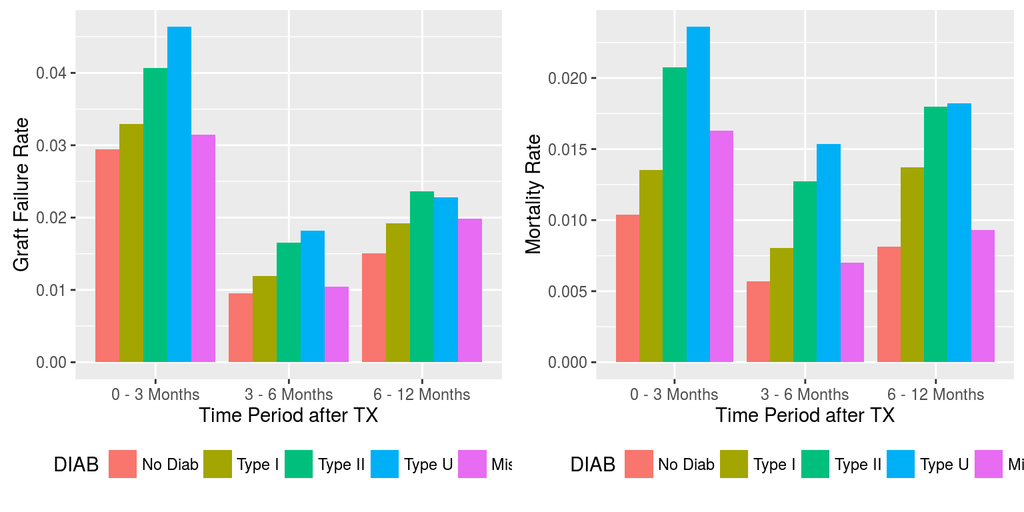

Using the subset of date with no diabetes, or Type I or Type II diabetes, we fit a Cox model with varying effects for diabetes. The cutting point for the time-varying coefficients are 3 months, 6 months and 12 months.

```
## Call:
## coxph(formula = Surv(T.GRF, D.GRF) ~ AGE + GENDER + ETHCAT +
##     DIAB:strata(tint) + PERIP_VASC + BMI + KDPIC + END_CPRA +
##     COLD_ISCH_KI + HLAMISM + strata(TX_CTR), data = unostd.g)
##
##   n= 312373, number of events= 15567
##    (40186 observations deleted due to missingness)
##
##                                      coef  exp(coef)   se(coef)      z Pr(>|z|)
## AGE                             0.0072155  1.0072416  0.0007155 10.085  < 2e-16 ***
## GENDERM                         0.1071034  1.1130494  0.0175463  6.104 1.03e-09 ***
## ETHCATBlack                     0.1056158  1.1113948  0.0204520  5.164 2.42e-07 ***
## ETHCATHispanic                 -0.2428639  0.7843783  0.0302339 -8.033 9.99e-16 ***
## ETHCATAsian                    -0.4068508  0.6657435  0.0442709 -9.190  < 2e-16 ***
## ETHCATOther                    -0.0016852  0.9983162  0.0664340 -0.025 0.979762
## PERIP_VASCYes                   0.3499316  1.4189705  0.0339118 10.319  < 2e-16 ***
## PERIP_VASCUnknown/Miss          0.2036917  1.2259201  0.0562164  3.623 0.000291 ***
## BMIUnderweight                  0.1585375  1.1717959  0.0612127  2.590 0.009599 **
## BMIOverweight                  -0.0055865  0.9944291  0.0211552 -0.264 0.791724
## BMIObese                        0.0533017  1.0547478  0.0211963  2.515 0.011914 *
## KDPICMiss                       0.6558300  1.9267410  0.0914074  7.175 7.24e-13 ***
## KDPIC0-10                       0.2381304  1.2688746  0.0436011  5.462 4.72e-08 ***
## KDPIC10-90                      0.5045699  1.6562731  0.0281773 17.907  < 2e-16 ***
## KDPIC90+                        1.0039200  2.7289585  0.0384850 26.086  < 2e-16 ***
## END_CPRA                        0.0022197  1.0022222  0.0002792  7.951 1.89e-15 ***
## COLD_ISCH_KI                    0.0039680  1.0039759  0.0010503  3.778 0.000158 ***
## HLAMISM3-4                      0.1401539  1.1504509  0.0254837  5.500 3.80e-08 ***
## HLAMISM5-6                      0.2132337  1.2376738  0.0256485  8.314  < 2e-16 ***
## DIABType I:strata(tint)tint=1   0.1198233  1.1272977  0.0857125  1.398 0.162123
## DIABType II:strata(tint)tint=1  0.1215111  1.1292019  0.0426480  2.849 0.004383 **
## DIABNo Diab:strata(tint)tint=1         NA         NA  0.0000000     NA       NA
## DIABType I:strata(tint)tint=2   0.2793430  1.3222608  0.1395398  2.002 0.045297 *
## DIABType II:strata(tint)tint=2  0.3326426  1.3946488  0.0688134  4.834 1.34e-06 ***
## DIABNo Diab:strata(tint)tint=2         NA         NA  0.0000000     NA       NA
## DIABType I:strata(tint)tint=3   0.2415557  1.2732284  0.1153802  2.094 0.036299 *
## DIABType II:strata(tint)tint=3  0.2758526  1.3176537  0.0564362  4.888 1.02e-06 ***
## DIABNo Diab:strata(tint)tint=3         NA         NA  0.0000000     NA       NA
## DIABType I:strata(tint)tint=4   0.2481802  1.2816908  0.0428335  5.794 6.87e-09 ***
## DIABType II:strata(tint)tint=4  0.2929405  1.3403631  0.0230614 12.703  < 2e-16 ***
## DIABNo Diab:strata(tint)tint=4         NA         NA  0.0000000     NA       NA
```

[output cut: 26 more lines]

```
## DIABType I:strata(tint)tint=2     1.3223     0.7563    1.0059    1.7382
## DIABType II:strata(tint)tint=2    1.3946     0.7170    1.2187    1.5960
## DIABNo Diab:strata(tint)tint=2        NA         NA        NA        NA
## DIABType I:strata(tint)tint=3     1.2732     0.7854    1.0155    1.5963
## DIABType II:strata(tint)tint=3    1.3177     0.7589    1.1797    1.4718
## DIABNo Diab:strata(tint)tint=3        NA         NA        NA        NA
## DIABType I:strata(tint)tint=4     1.2817     0.7802    1.1785    1.3939
## DIABType II:strata(tint)tint=4    1.3404     0.7461    1.2811    1.4023
## DIABNo Diab:strata(tint)tint=4        NA         NA        NA        NA
##
## Concordance= 0.622  (se = 0.053 )
## Rsquare= 0.009   (max possible= 0.429 )
## Likelihood ratio test= 2707  on 27 df,   p=0
## Wald test            = 2679  on 27 df,   p=0
## Score (logrank) test = 2787  on 27 df,   p=0
```

TOC

## Interaction between Dialysis Time and Diabetes

- both dialysis dates are non-missing and equal; use either one;
- both dialysis dates are non-missing and unequal, but one is after `TX_DATE`; use the one precedes `TX_DATE`;
- both dialysis dates are non-missing and unequal, and both precede `TX_DATE`; use `DIALYSIS_DATE`;
- only one of `DIAL_DATE` and `DIALYSIS_DATE` is missing; use the non-missing dialysis date in the calculation;
- `Preemptive`: both `DIAL_DATE` and `DIALYSIS_DATE` are missing and `DIAL_TRR == "N"`;
- `Miss`: both `DIAL_DATE` and `DIALYSIS_DATE` are missing and `DIAL_TRR != "N"`.

We inspect the one-year graft failure rate and the mortality rate for different combination of dialysis time and diabetes types.

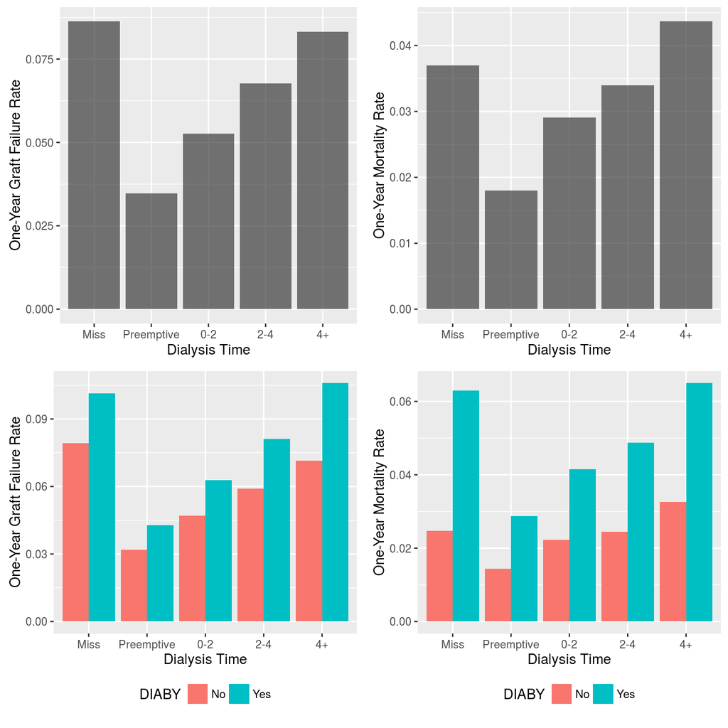

```
## Call:
## coxph(formula = Surv(T.GRF, D.GRF) ~ AGE + GENDER + ETHCAT +
##     DIABY * TDIALC + PERIP_VASC + BMI + KDPIC + END_CPRA + COLD_ISCH_KI +
##     HLAMISM + strata(TX_CTR), data = unos1)
##
##   n= 85007, number of events= 16326
##    (10678 observations deleted due to missingness)
##
##                              coef  exp(coef)   se(coef)       z Pr(>|z|)
## AGE                     0.0085831  1.0086200  0.0006935  12.376  < 2e-16 ***
## GENDERM                 0.0871690  1.0910811  0.0171308   5.088 3.61e-07 ***
## ETHCATBlack             0.0284650  1.0288740  0.0203078   1.402  0.16101
## ETHCATHispanic         -0.2997455  0.7410067  0.0294137 -10.191  < 2e-16 ***
## ETHCATAsian            -0.4490801  0.6382150  0.0430890 -10.422  < 2e-16 ***
## ETHCATOther            -0.1031342  0.9020059  0.0650393  -1.586  0.11280
## DIABYYes                0.3105868  1.3642254  0.0548442   5.663 1.49e-08 ***
## TDIALCMiss              0.4695433  1.5992636  0.1152822   4.073 4.64e-05 ***
## TDIALC0-2               0.4443488  1.5594743  0.0387681  11.462  < 2e-16 ***
## TDIALC2-4               0.4905299  1.6331814  0.0396909  12.359  < 2e-16 ***
## TDIALC4+                0.6375143  1.8917726  0.0389147  16.382  < 2e-16 ***
## PERIP_VASCYes           0.3089622  1.3620109  0.0333616   9.261  < 2e-16 ***
## PERIP_VASCUnknown/Miss  0.1024061  1.1078333  0.0491874   2.082  0.03735 *
## BMIUnderweight          0.1627756  1.1767726  0.0600079   2.713  0.00668 **
## BMIOverweight          -0.0072660  0.9927603  0.0206631  -0.352  0.72511
## BMIObese                0.0455573  1.0466109  0.0206205   2.209  0.02715 *
## KDPICMiss               0.5099917  1.6652774  0.0871739   5.850 4.91e-09 ***
## KDPIC0-10               0.1086951  1.1148223  0.0433937   2.505  0.01225 *
## KDPIC10-90              0.3585965  1.4313191  0.0288802  12.417  < 2e-16 ***
## KDPIC90+                0.8582207  2.3589596  0.0383314  22.389  < 2e-16 ***
## END_CPRA                0.0017723  1.0017739  0.0002735   6.481 9.09e-11 ***
## COLD_ISCH_KI            0.0041441  1.0041527  0.0010267   4.036 5.43e-05 ***
## HLAMISM3-4              0.1047699  1.1104550  0.0250611   4.181 2.91e-05 ***
## HLAMISM5-6              0.1849565  1.2031661  0.0252041   7.338 2.16e-13 ***
## DIABYYes:TDIALCMiss     0.1619907  1.1758494  0.1874838   0.864  0.38757
## DIABYYes:TDIALC0-2     -0.1384328  0.8707218  0.0632207  -2.190  0.02855 *
## DIABYYes:TDIALC2-4     -0.0504482  0.9508032  0.0624373  -0.808  0.41910
## DIABYYes:TDIALC4+      -0.0520943  0.9492393  0.0603845  -0.863  0.38830
## ---
## Signif. codes:  0 '***' 0.001 '**' 0.01 '*' 0.05 '.' 0.1 ' ' 1
##
```

[output cut: 20 more lines]

```
## KDPIC90+                  2.3590     0.4239    2.1882    2.5430
## END_CPRA                  1.0018     0.9982    1.0012    1.0023
## COLD_ISCH_KI              1.0042     0.9959    1.0021    1.0062
## HLAMISM3-4                1.1105     0.9005    1.0572    1.1664
## HLAMISM5-6                1.2032     0.8311    1.1452    1.2641
## DIABYYes:TDIALCMiss       1.1758     0.8504    0.8143    1.6980
## DIABYYes:TDIALC0-2        0.8707     1.1485    0.7692    0.9856
## DIABYYes:TDIALC2-4        0.9508     1.0517    0.8413    1.0746
## DIABYYes:TDIALC4+         0.9492     1.0535    0.8433    1.0685
##
## Concordance= 0.63  (se = 0.027 )
## Rsquare= 0.038   (max possible= 0.887 )
## Likelihood ratio test= 3271  on 28 df,   p=0
## Wald test            = 3153  on 28 df,   p=0
## Score (logrank) test = 3320  on 28 df,   p=0
```

```
## Call:
## coxph(formula = Surv(T.PT, D.PT) ~ AGE + GENDER + ETHCAT + DIABY *
##     TDIALC + PERIP_VASC + BMI + KDPIC + END_CPRA + COLD_ISCH_KI +
##     HLAMISM + strata(TX_CTR), data = unos1)
##
##   n= 85007, number of events= 10486
##    (10678 observations deleted due to missingness)
##
##                              coef  exp(coef)   se(coef)       z Pr(>|z|)
## AGE                     0.0420964  1.0429951  0.0009642  43.661  < 2e-16 ***
## GENDERM                 0.1492053  1.1609113  0.0218803   6.819 9.16e-12 ***
## ETHCATBlack            -0.2332186  0.7919804  0.0261026  -8.935  < 2e-16 ***
## ETHCATHispanic         -0.4329166  0.6486146  0.0371980 -11.638  < 2e-16 ***
## ETHCATAsian            -0.6091689  0.5438026  0.0543799 -11.202  < 2e-16 ***
## ETHCATOther            -0.1941732  0.8235153  0.0801985  -2.421 0.015471 *
## DIABYYes                0.5066380  1.6597020  0.0662072   7.652 1.98e-14 ***
## TDIALCMiss              0.3622592  1.4365713  0.1604847   2.257 0.023990 *
## TDIALC0-2               0.4462033  1.5623690  0.0518459   8.606  < 2e-16 ***
## TDIALC2-4               0.4839483  1.6224678  0.0528595   9.155  < 2e-16 ***
## TDIALC4+                0.7498748  2.1167350  0.0512881  14.621  < 2e-16 ***
## PERIP_VASCYes           0.4072798  1.5027246  0.0370811  10.984  < 2e-16 ***
## PERIP_VASCUnknown/Miss  0.0276074  1.0279920  0.0607817   0.454 0.649682
## BMIUnderweight          0.3328647  1.3949586  0.0757178   4.396 1.10e-05 ***
## BMIOverweight          -0.0972540  0.9073255  0.0257832  -3.772 0.000162 ***
## BMIObese               -0.0589797  0.9427259  0.0260021  -2.268 0.023313 *
## KDPICMiss               0.6057374  1.8326032  0.1065902   5.683 1.32e-08 ***
## KDPIC0-10               0.3249723  1.3839923  0.0539114   6.028 1.66e-09 ***
## KDPIC10-90              0.4454163  1.5611399  0.0372024  11.973  < 2e-16 ***
## KDPIC90+                0.7933727  2.2108404  0.0477356  16.620  < 2e-16 ***
## END_CPRA                0.0020737  1.0020759  0.0003547   5.846 5.03e-09 ***
## COLD_ISCH_KI            0.0011462  1.0011468  0.0013039   0.879 0.379381
## HLAMISM3-4              0.0539266  1.0554071  0.0309023   1.745 0.080973 .
## HLAMISM5-6              0.1264146  1.1347525  0.0310881   4.066 4.78e-05 ***
## DIABYYes:TDIALCMiss     0.3308402  1.3921373  0.2320908   1.425 0.154019
## DIABYYes:TDIALC0-2     -0.1381857  0.8709370  0.0771076  -1.792 0.073114 .
## DIABYYes:TDIALC2-4     -0.0126930  0.9873872  0.0762063  -0.167 0.867715
## DIABYYes:TDIALC4+      -0.0486104  0.9525521  0.0732122  -0.664 0.506712
## ---
## Signif. codes:  0 '***' 0.001 '**' 0.01 '*' 0.05 '.' 0.1 ' ' 1
##
```

[output cut: 20 more lines]

```
## KDPIC90+                  2.2108     0.4523    2.0134    2.4277
## END_CPRA                  1.0021     0.9979    1.0014    1.0028
## COLD_ISCH_KI              1.0011     0.9989    0.9986    1.0037
## HLAMISM3-4                1.0554     0.9475    0.9934    1.1213
## HLAMISM5-6                1.1348     0.8812    1.0677    1.2060
## DIABYYes:TDIALCMiss       1.3921     0.7183    0.8833    2.1940
## DIABYYes:TDIALC0-2        0.8709     1.1482    0.7488    1.0130
## DIABYYes:TDIALC2-4        0.9874     1.0128    0.8504    1.1464
## DIABYYes:TDIALC4+         0.9526     1.0498    0.8252    1.0995
##
## Concordance= 0.707  (se = 0.034 )
## Rsquare= 0.065   (max possible= 0.746 )
## Likelihood ratio test= 5671  on 28 df,   p=0
## Wald test            = 5062  on 28 df,   p=0
## Score (logrank) test = 5495  on 28 df,   p=0
```

TOC